# Predicting the Present - Unemployment

Gabrielle Martinez (Pace University)

6/25/2020

## Recreating the model from the paper using the source data

Initial unemployment stats from the Department of Labor: https://oui.doleta.gov/unemploy/claims.asp for the years 2004-2020

Load in data for cleaning and reformatting

nsa = Not Seasonally Adjusted sa = Seasonally Adjusted

We’ll be starting off using Nonadjusted data (nsa)

```r
unemployment <- read.csv("unemployment_initial.csv")

unemployment %>%
  select(Period, nsa, sa) %>%
  mutate(Period = as.Date(Period, format="%m/%d/%Y")) -> unemployment

unemployment %>%
  mutate(last_month_claims = lag(nsa, 1)) %>%
  filter(Period >= ' 2004-01-17' & Period <= '2011-07-02') %>%
  mutate(check = format(Period, "%Y-%m")) -> unemployment_2011

#load trends data
jobs <- read.csv("jobs_2011.csv")

welfare <- read.csv("welfare_2011.csv")

#reformat trends data
jobs %>%
  rename("jobs"="Geo..United.States") -> jobs

welfare %>%
  rename("welfare"="Geo..United.States") -> welfare


#seasonal adjustment of jobs trends data

ts(jobs$jobs, start = c(2004,1), frequency = 12) -> ts

stl(ts, s.window = "periodic") -> stl

stl[["time.series"]]-> ts

ts[,"trend"] -> ts

broom::tidy(ts) -> ts

ts %>%
  mutate(date = date_decimal(index))%>%
  mutate(new_date = ceiling_date(date, "day")) %>%
  mutate(period = format(new_date, "%Y-%m")) -> ts

inner_join(jobs, ts, by = c("Month" = "period")) %>%
  select(Month, jobs, sa_jobs = value) -> jobs


#seasonal adjustment of welfare trends data

ts(welfare$welfare, start = c(2004,1), frequency = 12) -> ts

stl(ts, s.window = "periodic") -> stl

stl[["time.series"]]-> ts

ts[,"trend"] -> ts

broom::tidy(ts) -> ts

ts %>%
  mutate(date = date_decimal(index))%>%
  mutate(new_date = ceiling_date(date, "day")) %>%
  mutate(period = format(new_date, "%Y-%m")) -> ts

inner_join(welfare, ts, by = c("Month" = "period")) %>%
  select(Month, welfare, sa_welfare = value) -> welfare


#join with trends data
left_join(unemployment_2011, jobs, by=c("check"="Month")) -> unemployment_2011
left_join(unemployment_2011, welfare, by=c("check"="Month")) -> unemployment_2011

unemployment_2011 %>%
  select(-check) -> unemployment_2011
```

Let’s see what we’re working with.

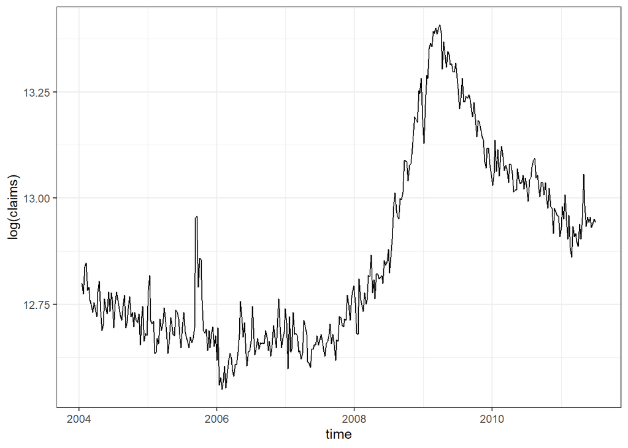

```r
ggplot(unemployment_2011) +
  geom_line(aes(y=log(sa), x=Period)) +
  ylab("log(claims)") +
  xlab("time")
```

### Remaking the in-sample models

> “In this case, our baseline regression is a simple AR-1 model on the log of initial claims.” [(Choi & Varian, 2011)](http://people.ischool.berkeley.edu/~hal/Papers/2011/ptp.pdf)

```r
#unadjusted data
base_model <- lm(log(nsa) ~ log(last_month_claims), data = unemployment_2011)
tidy(base_model)
```

```
## # A tibble: 2 x 5
##   term                   estimate std.error statistic   p.value
##   <chr>                     <dbl>     <dbl>     <dbl>     <dbl>
## 1 (Intercept)               1.35     0.284       4.78 2.52e-  6
## 2 log(last_month_claims)    0.894    0.0221     40.5  1.72e-141
```

```r
glance(base_model)
```

```
## # A tibble: 1 x 11
##   r.squared adj.r.squared sigma statistic   p.value    df logLik   AIC   BIC
##       <dbl>         <dbl> <dbl>     <dbl>     <dbl> <int>  <dbl> <dbl> <dbl>
## 1     0.809         0.808 0.121     1642. 1.72e-141     2   273. -540. -528.
## # ... with 2 more variables: deviance <dbl>, df.residual <int>
```

```r
trend_model <- lm(log(nsa) ~ log(last_month_claims) + jobs + welfare, unemployment_2011)
tidy(trend_model)
```

```
## # A tibble: 4 x 5
##   term                   estimate std.error statistic  p.value
##   <chr>                     <dbl>     <dbl>     <dbl>    <dbl>
## 1 (Intercept)             2.87     0.390         7.35 1.19e-12
## 2 log(last_month_claims)  0.783    0.0314       25.0  1.37e-82
## 3 jobs                   -0.00256  0.000570     -4.48 9.70e- 6
## 4 welfare                 0.00177  0.000670      2.64 8.59e- 3
```

```r
glance(trend_model)
```

```
## # A tibble: 1 x 11
##   r.squared adj.r.squared sigma statistic   p.value    df logLik   AIC   BIC
##       <dbl>         <dbl> <dbl>     <dbl>     <dbl> <int>  <dbl> <dbl> <dbl>
## 1     0.825         0.823 0.116      605. 1.58e-145     4   290. -570. -550.
## # ... with 2 more variables: deviance <dbl>, df.residual <int>
```

We get very different results from the paper when using the non-adjusted data to make our models. It maybe the case that we made a mistake when adjusting the trends data because the paper fails to describe how they adjusted the data beyond what function they used (`stl`).

We know the authors used seasonally adjusted data and thus adjusted the trends data to match. Let’s try that.

```r
base_model_sa <- lm(log(sa) ~ log(last_month_claims), data = unemployment_2011)
tidy(base_model_sa)
```

```
## # A tibble: 2 x 5
##   term                   estimate std.error statistic  p.value
##   <chr>                     <dbl>     <dbl>     <dbl>    <dbl>
## 1 (Intercept)               5.06     0.332       15.2 1.86e-41
## 2 log(last_month_claims)    0.608    0.0258      23.5 9.68e-77
```

```r
glance(base_model_sa)
```

```
## # A tibble: 1 x 11
##   r.squared adj.r.squared sigma statistic  p.value    df logLik   AIC   BIC
##       <dbl>         <dbl> <dbl>     <dbl>    <dbl> <int>  <dbl> <dbl> <dbl>
## 1     0.588         0.587 0.141      554. 9.68e-77     2   212. -417. -406.
## # ... with 2 more variables: deviance <dbl>, df.residual <int>
```

```r
trend_model_sa <- lm(log(sa) ~ log(last_month_claims) + sa_jobs + sa_welfare, unemployment_2011)
tidy(trend_model_sa)
```

```
## # A tibble: 4 x 5
##   term                   estimate std.error statistic  p.value
##   <chr>                     <dbl>     <dbl>     <dbl>    <dbl>
## 1 (Intercept)             8.82     0.315        28.0  4.75e-95
## 2 log(last_month_claims)  0.278    0.0252       11.0  1.10e-24
## 3 sa_jobs                -0.00159  0.000644     -2.47 1.39e- 2
## 4 sa_welfare              0.0105   0.000702     15.0  2.53e-40
```

```r
glance(trend_model_sa)
```

```
## # A tibble: 1 x 11
##   r.squared adj.r.squared sigma statistic   p.value    df logLik   AIC   BIC
##       <dbl>         <dbl> <dbl>     <dbl>     <dbl> <int>  <dbl> <dbl> <dbl>
## 1     0.790         0.788 0.101      483. 3.03e-130     4   343. -675. -656.
## # ... with 2 more variables: deviance <dbl>, df.residual <int>
```

My R^2 are far smaller than the paper’s but Basira had better luck than me in that department. While her coefficients much more closely align with the paper’s, we both got intercepts that were much higher than the paper’s.

Let’s see how these models look plotted

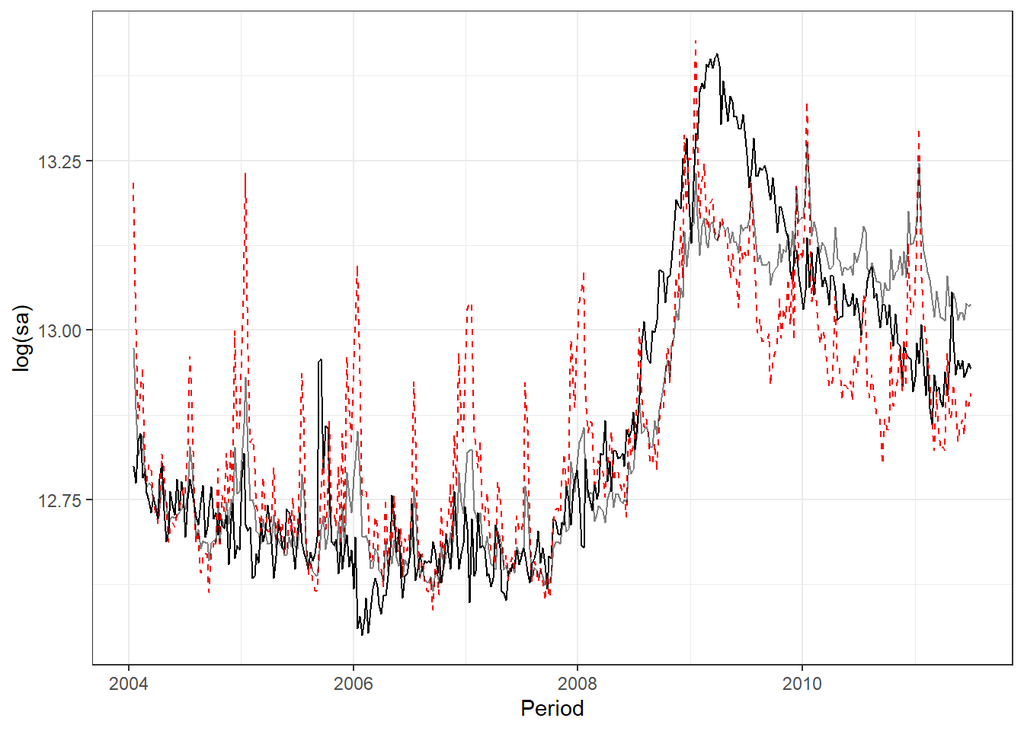

```r
unemployment_2011 %>%
  add_predictions(base_model_sa, "base") %>%
  add_predictions(trend_model_sa, "trend") -> unemployment_2011_pred


ggplot(unemployment_2011_pred) +
  geom_line(aes(y=log(sa), x=Period)) +
  geom_line(aes(y=base,x= Period), color = "red", linetype = "dashed") +
  geom_line(aes(y=trend,x= Period), alpha = .5)
```

### Remaking Out-of-sample forecast model